# Study the ways of people knowing about and getting involved in election campaigns

In the introduction file, we analyzed the relationship between racial groups and voting preference. In this R notebook, I would like to study the ways of people engaging in election campaigns. I use data of election surveys from American National Election Studies (ANES). The raw data has over thousand columns, and I clean the data by choosing and renaming 6 of them. Here is a sample of my cleaned data.

| year | age | activity | tv | radio | read |
| --- | --- | --- | --- | --- | --- |
| 2004 | 1. 17 - 24 | 2 | 2. Yes, watched TV program(s) about the campaign [a | 1. No, didn't listen to radio programs about campaign | 2. Yes, read magazine(s) [quite a lot (1952), not very |
| 1960 | 1. 17 - 24 | 1. Lowest level of participation (none) | 2. Yes, watched TV program(s) about the campaign [a | 1. No, didn't listen to radio programs about campaign | 1. No, didn't read magazines about the campaign |
| 1956 | 6. 65 - 74 | 2 | 2. Yes, watched TV program(s) about the campaign [a | 2. Yes, listened to radio program(s) [quite a lot | 2. Yes, read magazine(s) [quite a lot (1952), not very |
| 1984 | 1. 17 - 24 | 1. Lowest level of participation (none) | 1. No, didn't watch TV programs about the campaign | 2. Yes, listened to radio program(s) [quite a lot | 1. No, didn't read magazines about the campaign |
| 1972 | 7. 75 - 99 and over (except 1954) | 1. Lowest level of participation (none) | 2. Yes, watched TV program(s) about the campaign [a | 2. Yes, listened to radio program(s) [quite a lot | 2. Yes, read magazine(s) [quite a lot (1952), not very |
| 1960 | 5. 55 - 64 | 1. Lowest level of participation (none) | 2. Yes, watched TV program(s) about the campaign [a | 1. No, didn't listen to radio programs about campaign | 1. No, didn't read magazines about the campaign |
| 1956 | 4. 45 - 54 | 1. Lowest level of participation (none) | 2. Yes, watched TV program(s) about the campaign [a | 1. No, didn't listen to radio programs about campaign | 2. Yes, read magazine(s) [quite a lot (1952), not very |
| 1976 | 7. 75 - 99 and over (except 1954) | 1. Lowest level of participation (none) | 2. Yes, watched TV program(s) about the campaign [a | 2. Yes, listened to radio program(s) [quite a lot | 1. No, didn't read magazines about the campaign |
| 1980 | 1. 17 - 24 | 1. Lowest level of participation (none) | 1. No, didn't watch TV programs about the campaign | 1. No, didn't listen to radio programs about campaign | 1. No, didn't read magazines about the campaign |
| 1992 | 5. 55 - 64 | 2 | 2. Yes, watched TV program(s) about the campaign [a | 2. Yes, listened to radio program(s) [quite a lot | 1. No, didn't read magazines about the campaign |

[output cut: 20 more lines]

# Question 1:Generally, in which way would people like to get involved in election campaigns?

```
                 1. Lowest level of participation (none)
                                                   20684
                                                       2
                                                   11273
                                                       3
                                                    1628
4. Highest level of participation in campaign activities
                                                     678
2. Yes, watched TV program(s) about the campaign [a
                                              21752
2. Yes, listened to radio program(s) [quite a lot
                                             9849
2. Yes, read magazine(s) [quite a lot (1952), not very
                                                  7055
```

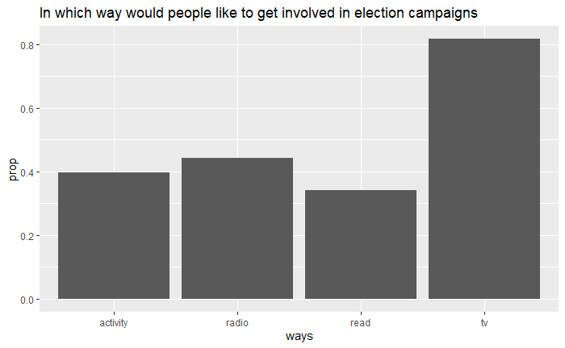

Ignoring the NA data, I count the number of people for each of the 4 ways and compute the proportions. It should be noticed that the ways of getting involved in election campaigns are not exclusive choices, so the sum of proportions here is more than 1. Not surprisingly, watching television is the most popular way for people to participate in election campaigns.

The conclusion here is too general. Since the data contains respondents of all age groups and data over 60 years, I would like to see whether the ways that people choose change with their ages and the eras.

# Question 2: How do people of different ages engage in election campaigns in different years?

Let’s look at the four ways separately.

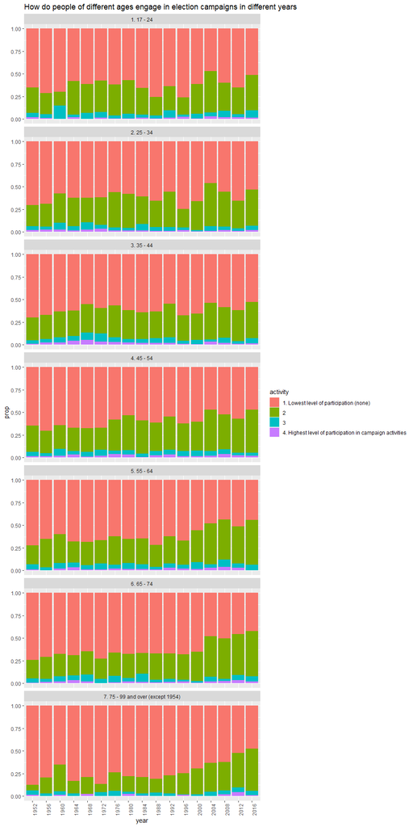

1.The graph above shows that overall, younger people would be more willing to take part in campaign activities.

2.Also I have an interesting finding here. After 2000, people participate in campaign activities more and more.

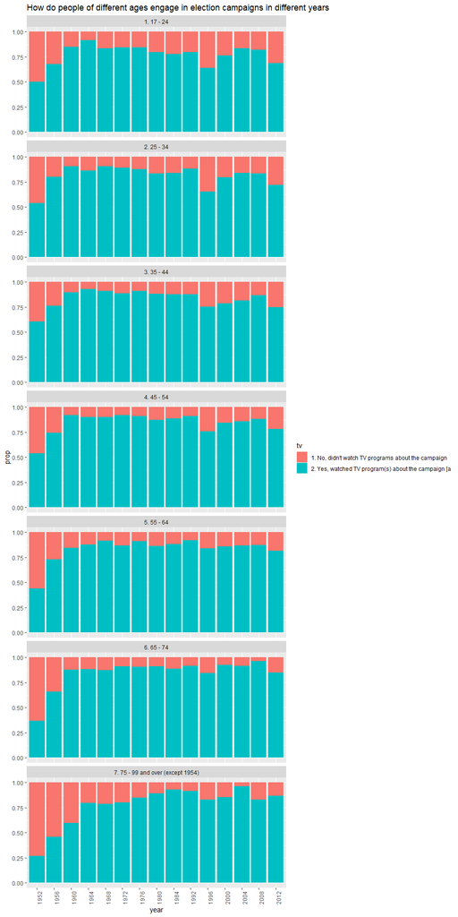

1.We can clearly see that people of all age group love to know about election campaigns through television.

2.Here is an obviously increasing trend between 1952 and 1960. This increase may be closely related to the prevalence of TV at that time.

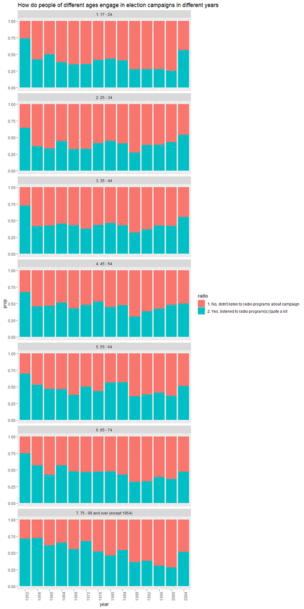

2.In 1952, radio was still a popular way for people of all age groups, but the proportion suddenly decreased in 1956. This may also cause by the the prevalence of TV.

3.The decrease in proportion for the 7th age group is not obvious. They may had get used to listening to radio programs., and it is hard for older people to change their habits.

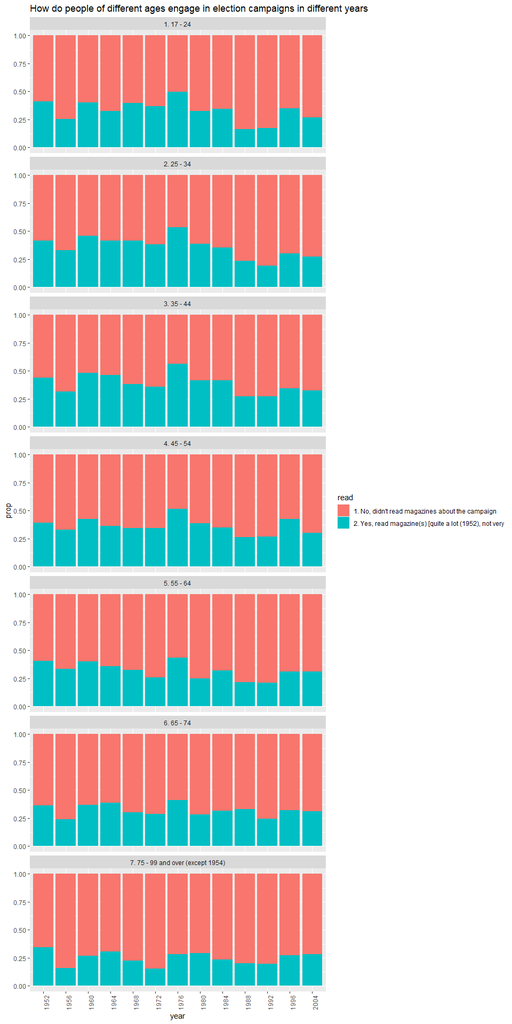

# Summary

1.In general, watching TV > listening to radio programs > participating in activities > reading magazine.(Here, “>” means “is more popular than”)

2.Participating in activities is more popular among younger people, but more and more people are willing to choose this way with year.

3.Watching TV has been the most popular way for people of all ages after the the prevalence of TV.

4.Listening to radio programs was the most popular way for people of all ages, but then was overtaken by watching TV after the the prevalence of TV.